# Assignment_12

Matthew Schultz

2023-03-31

# This is my test example for an R markdown script

## This first code chunk will be used to install required packages.

For the sake of the assignment, I will keep the packages simple. Note that the `echo = TRUE` parameter was added to the code chunk to prevent to keep the packages listed in the html.

```r
library(tidyverse)
```

## I will now load the data set into R

The mtcars package is one of the most popular used data sets. It will be a good start for this test. Here is a [link](https://stat.ethz.ch/R-manual/R-devel/library/datasets/html/mtcars.html) to a fleshed out explanation of the data set.

```r
cars <- mtcars
```

I will include a page break here

Now I will want to include a few different plots.

### Scatter Plot measuring engine displacement and mpg

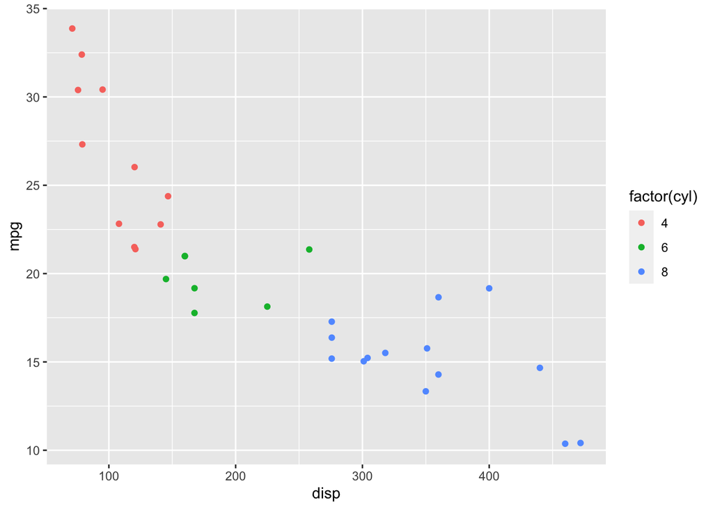

```r
ggplot(cars, aes(disp, mpg, color=factor(cyl))) +
  geom_jitter()
```

This plot does not have very descriptive headers to mark the data. For this we will need to include `labs(title = "Descriptive Title"`.

### Adding descriptive titles to ggplot graphs

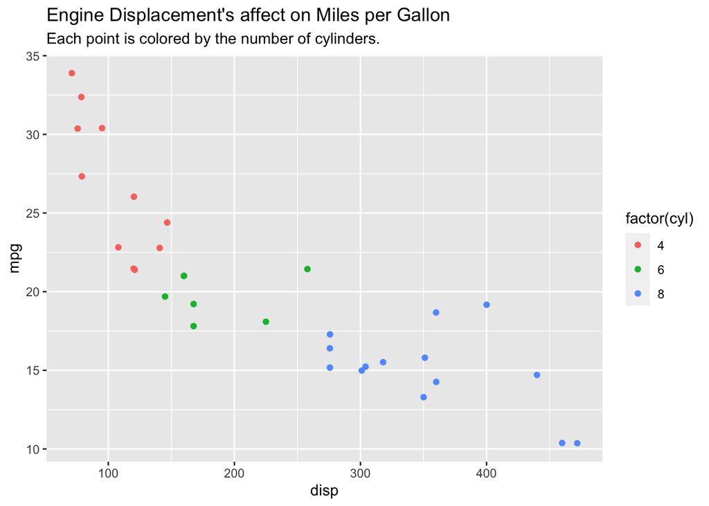

```r
ggplot(cars, aes(disp, mpg, color=factor(cyl))) +
  geom_jitter() +
  labs(
    title = "Engine Displacement's affect on Miles per Gallon",
    subtitle = "Each point is colored by the number of cylinders."
  )
```

## Conclusion

Here is what we learned so far:

- The impact of `echo` within an R code chunks
- How to include links into the data set with `[text](link)`
- How to include inline pieces of code with double `
- How to include list with *
- That pound signs con produce different heading for the script